# walkthrough.R

alex

Fri Sep 19 09:20:39 2014

Visualizing character data on trees

```r
library(ape)
library(diversitree)
```

```r
source('/Users/alex/GitHub/traitathon/treeOfSex/plot_trait_dendrogram.R')
source('/Users/alex/GitHub/traitathon/treeOfSex/get_tos_database.R')
```

Example 1: Plotting binary flower color character states onto Solanaceae data  
Here we already have a tree and a character matrix  
First, read in the tree with ape() and the character matrix, too.

```r
sol_tree <- read.tree("/Users/alex/GitHub/traitathon/solanaceae/Solanaceae.tre")
sol_char <- read.csv("/Users/alex/GitHub/traitathon/solanaceae/SolanaceaeTraits.csv", row.names=1)
```

Then make sure the character matrix rows are in the same order as the tree tips. This is essential, otherwise they won’t match up on the tree.

```r
sol_char <- sol_char[sol_tree$tip.label, ]
```

We only have one binary character that we want to map onto the tree, so we can plot that single column.

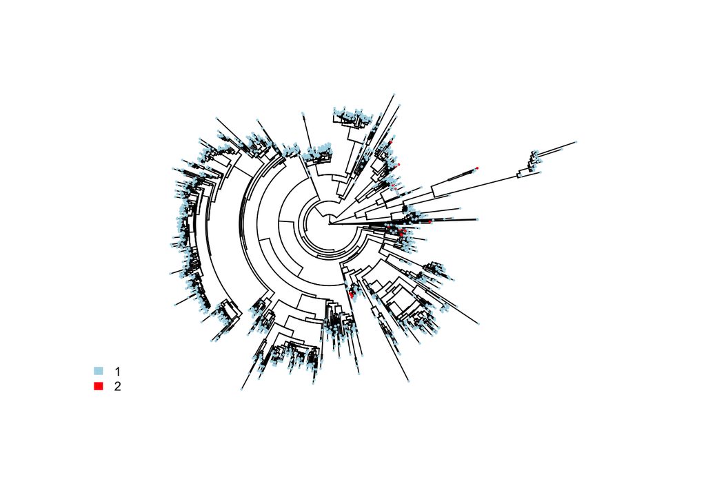

```r
plot_trait_dendrogram(sol_tree, sol_char, legend=TRUE, binary=TRUE, tree_type="fan", tiplabel_cex=0.2)
```

Example 2: Visualizing discrete traits from Anolis  
Again, here we have a user-provided tree and character matrix

```r
anolis_tree <- read.tree("/Users/alex/GitHub/traitathon/anolis/anolis.phy")
anolis_char <- read.csv("/Users/alex/GitHub/traitathon/anolis/anolis.csv", row.names=1)
```

Make sure the character matrix rows are in the same order as the tree tips

```r
anolis_char <- anolis_char[anolis_tree$tip.label, ]
```

Pick out the character trait to plot on the tree. Here I extract what islands each species is native to.

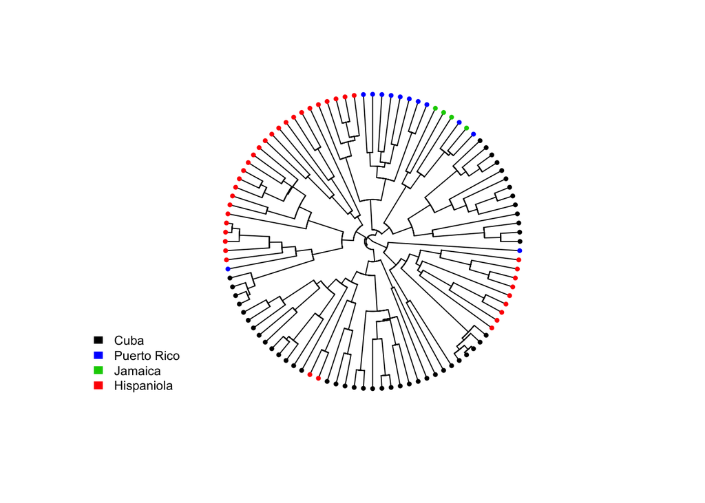

```r
anolis_char <- anolis_char$island

plot_trait_dendrogram(anolis_tree, anolis_char, legend=TRUE, binary=FALSE, tree_type="fan", tiplabel_cex=0.5)
```

Maybe this would look better as a regular phylogram…

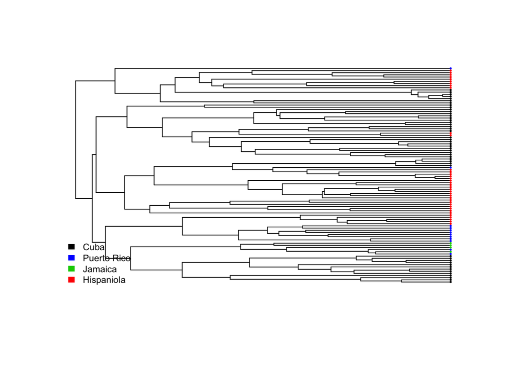

```r
plot_trait_dendrogram(anolis_tree, anolis_char, legend=TRUE, binary=FALSE, tree_type="phylogram", tiplabel_cex=0.25)
```

```r
helic_tree <- read.tree("/Users/alex/GitHub/traitathon/heliconia/heliconia.phy")
helic_char <- read.csv("/Users/alex/GitHub/traitathon/heliconia/heliconia1.csv", row.names=1)
```

Again, let’s make sure the rownames of the character matrix match up with the tree tips

```r
helic_char <- helic_char[helic_tree$tip.label, ]
```

Let’s pick out a character trait to plot, like flower arrangement, or perianth color

```r
helic_arrangement <- helic_char$arrangment
helic_color <- helic_char$perColor
```

Now plot it

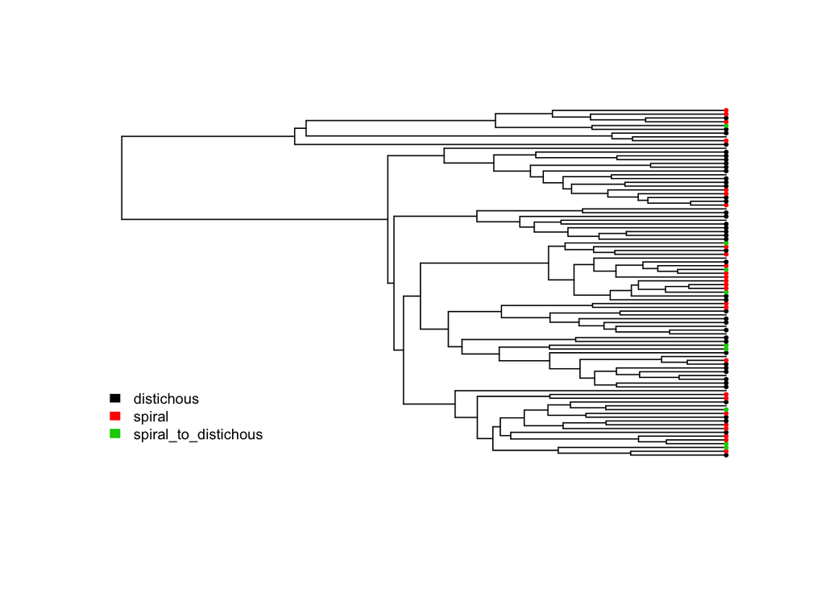

```r
plot_trait_dendrogram(helic_tree, helic_arrangement, legend=TRUE, binary=FALSE, tree_type="phylogram", tiplabel_cex=0.4, legend_loc="bottomleft")
```

First let’s extract some data from the Tree of Sex  
# rename

```r
plant_sex <- get_tos_database("plant")
```

```
## loading plant db
```

What traits are in this database?

```r
colnames(plant_sex)
```

```
##  [1] "kingdom"                "higher_taxonomic_group"
##  [3] "order"                  "family"
##  [5] "genus"                  "species"
##  [7] "species_author"         "infraspecific"
##  [9] "common_name"            "hybrid"
## [11] "hybrid_source"          "plant_list_status"
## [13] "plant_list_name"        "sexual_system"
## [15] "sexual_system_source"   "selfing"
## [17] "selfing_source"         "growth_form"
## [19] "growth_form_source"     "woodiness"
## [21] "woodiness_count"        "woodiness_source"
## [23] "life_form"              "life_form_source"
## [25] "gametophytic_n"         "gametophytic_n_min"
## [27] "gametophytic_n_mean"    "gametophytic_n_source"
## [29] "sporophytic_n"          "sporophytic_n_min"
## [31] "sporophytic_n_mean"     "sporophytic_n_source"
## [33] "karyotype"              "karyotype_source"
## [35] "molecular_basis"        "molecular_basis_source"
## [37] "genotype"               "genotype_source"
## [39] "notes"                  "entry_email"
```

Let’s reformat this data a little bit. We want the rownames to be “Genus species”.

```r
new_rownames <- paste(plant_sex$genus,plant_sex$species, sep=" ")
rownames(plant_sex) <- make.names(new_rownames, unique=TRUE)
rownames(plant_sex) <- as.character(sub("\\."," ", rownames(plant_sex)))
head(rownames(plant_sex))
```

```
## [1] "Acer acuminatum"
## [2] "Acer albopurpurascens"
## [3] "Acer albopurpurascens...buergerianum"
## [4] "Acer amamiense"
## [5] "Acer amplum"
## [6] "Acer argutum"
```

Now we can extract some information…like sexual systems in the solanaceae example  
The tree tip labels in the solanacea have underscores in them, let’s change that real quick to match our Tree of Sex data

```r
head(sol_tree$tip.label)
```

```
## [1] "Vestia_foetida"          "Protoschwenkia_mandonii"
## [3] "Browallia_americana"     "Browallia_eludens"
## [5] "Browallia_speciosa"      "Streptosolen_jamesonii"
```

```r
sol_tree$tip.label <- sub("_"," ",sol_tree$tip.label)
head(sol_tree$tip.label)
```

```
## [1] "Vestia foetida"          "Protoschwenkia mandonii"
## [3] "Browallia americana"     "Browallia eludens"
## [5] "Browallia speciosa"      "Streptosolen jamesonii"
```

Now extract the Tree of Sex “sexual system” data for leaves in our tree. If there’s no entry for a tip species in the Tree of Sex database, title it “unknown”

```r
tipchars <- ifelse(sol_tree$tip.label %in% rownames(plant_sex),plant_sex$sexual_system,NA)
sex_levels <- levels(plant_sex$sexual_system)
solanacea_sex <- sex_levels[tipchars]
solanacea_sex[is.na(solanacea_sex)] <- "unknown"
solanacea_sex <- as.factor(solanacea_sex)
```

let’s see if it worked…!

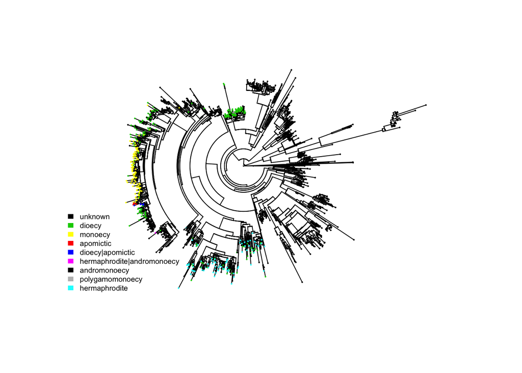

```r
plot_trait_dendrogram(sol_tree, solanacea_sex, tree_type="fan", tiplabel_cex=0.15, legend=TRUE, legend_loc="bottomleft", legend_cex=0.6)
```

Whoops. There are two conditions colored black; we need more colors in our color palette. Here’s how we could fix that

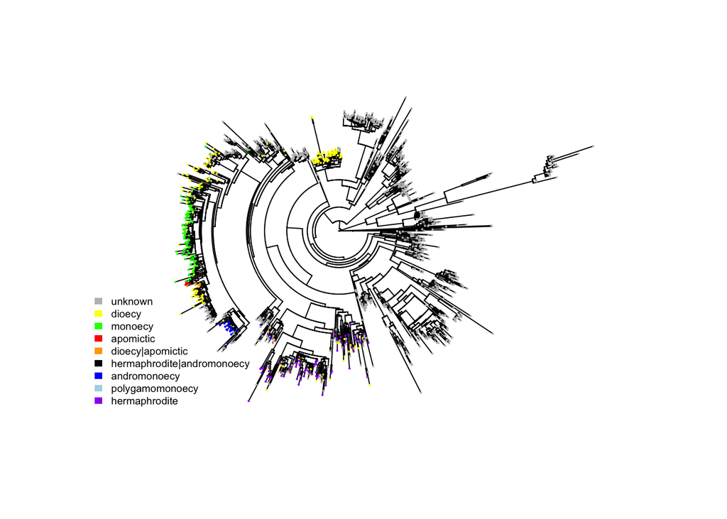

```r
palette(c("blue","red", "yellow","orange","purple","black","green","lightblue","grey"))
plot_trait_dendrogram(sol_tree, solanacea_sex, tree_type="fan", tiplabel_cex=0.15, legend=TRUE, legend_loc="bottomleft", legend_cex=0.6)
```